# Projecting Fantasy Football Points Using Current Game Status

#### December 2022

## 1. Introduction

### 1.1 What is Fantasy Football?

Fantasy football is an online game for people who watch the NFL in which competitors form leagues (typically of size 8-16) with friends and draft NFL players to compete for them. Each NFL play awards points to fantasy players based on their performance on a given play. There are a few different popular scoring methods, but in this project, I will focus on scoring from a typical "PPR" league, which works as follows:

- 1 point to the receiver for a reception
- 0.1 points per receiving yard
- 0.1 points per rushing yard
- 6 points for a rushing or receiving touchdown
- 0.04 points per passing yard
- 4 points for a passing touchdown

There are a few other ways to gain or lose points (such as fumbling) but for the purposes of this project, I'll stick to the list above. Also, we are only going to be dealing with receivers, running backs, and qbs, so tight ends, defenses and kickers will be excluded.

## 2. Acquiring Data

### 2.1 nfl-data-py

```python
# suppress output
%%capture
!pip install nfl_data_py
```

```python
import nfl_data_py as nfl
import numpy as np
import pandas as pd
import matplotlib.pyplot as plt
import seaborn as sns
import requests
from collections import defaultdict
from sklearn.metrics import r2_score
from sklearn import linear_model
from sklearn import neighbors
from sklearn.tree import DecisionTreeRegressor
import statsmodels.api as sm
import statsmodels.formula.api as smf
from scipy import stats
```

```python
team_desc = nfl.import_team_desc() # Importing team description table
team_desc.head()
```

|  | team_abbr | team_name | team_id | team_nick | team_conf | team_division | team_color | team_color2 | team_color3 | team_color4 | team_logo_wikipedia | team_logo_espn | team_wordmark | team_conference_logo | team_league_logo | team_logo_squared |
| --- | --- | --- | --- | --- | --- | --- | --- | --- | --- | --- | --- | --- | --- | --- | --- | --- |
| 0 | ARI | Arizona Cardinals | 3800 | Cardinals | NFC | NFC West | #97233F | #000000 | #ffb612 | #a5acaf | https://upload.wikimedia.org/wikipedia/en/thum... | https://a.espncdn.com/i/teamlogos/nfl/500/ari.png | https://github.com/nflverse/nflverse-pbp/raw/m... | https://github.com/nflverse/nflverse-pbp/raw/m... | https://raw.githubusercontent.com/nflverse/nfl... | https://github.com/nflverse/nflverse-pbp/raw/m... |
| 1 | ATL | Atlanta Falcons | 200 | Falcons | NFC | NFC South | #A71930 | #000000 | #a5acaf | #a30d2d | https://upload.wikimedia.org/wikipedia/en/thum... | https://a.espncdn.com/i/teamlogos/nfl/500/atl.png | https://github.com/nflverse/nflverse-pbp/raw/m... | https://github.com/nflverse/nflverse-pbp/raw/m... | https://raw.githubusercontent.com/nflverse/nfl... | https://github.com/nflverse/nflverse-pbp/raw/m... |
| 2 | BAL | Baltimore Ravens | 325 | Ravens | AFC | AFC North | #241773 | #9E7C0C | #9e7c0c | #c60c30 | https://upload.wikimedia.org/wikipedia/en/thum... | https://a.espncdn.com/i/teamlogos/nfl/500/bal.png | https://github.com/nflverse/nflverse-pbp/raw/m... | https://github.com/nflverse/nflverse-pbp/raw/m... | https://raw.githubusercontent.com/nflverse/nfl... | https://github.com/nflverse/nflverse-pbp/raw/m... |
| 3 | BUF | Buffalo Bills | 610 | Bills | AFC | AFC East | #00338D | #C60C30 | #0c2e82 | #d50a0a | https://upload.wikimedia.org/wikipedia/en/thum... | https://a.espncdn.com/i/teamlogos/nfl/500/buf.png | https://github.com/nflverse/nflverse-pbp/raw/m... | https://github.com/nflverse/nflverse-pbp/raw/m... | https://raw.githubusercontent.com/nflverse/nfl... | https://github.com/nflverse/nflverse-pbp/raw/m... |
| 4 | CAR | Carolina Panthers | 750 | Panthers | NFC | NFC South | #0085CA | #000000 | #bfc0bf | #0085ca | https://upload.wikimedia.org/wikipedia/en/thum... | https://a.espncdn.com/i/teamlogos/nfl/500-dark... | https://github.com/nflverse/nflverse-pbp/raw/m... | https://github.com/nflverse/nflverse-pbp/raw/m... | https://raw.githubusercontent.com/nflverse/nfl... | https://github.com/nflverse/nflverse-pbp/raw/m... |

```python
# Importing rosters table with our chosen columns
rosters = nfl.import_rosters(range(2016, 2022), ['season', 'team', 'position',
                                                 'player_name', 'player_id'])

# Restrict to only rbs, wrs, and qbs
rosters = rosters.loc[rosters['position'].isin(['RB', 'WR', 'QB'])]
rosters.head()
```

|  | season | team | position | player_name | player_id |
| --- | --- | --- | --- | --- | --- |
| 53 | 2016 | ARI | QB | Carson Palmer | 00-0021429 |
| 54 | 2016 | ARI | QB | Drew Stanton | 00-0025430 |
| 55 | 2016 | ARI | QB | Zac Dysert | 00-0030394 |
| 56 | 2016 | ARI | RB | Chris Johnson | 00-0026164 |
| 57 | 2016 | ARI | RB | Stepfan Taylor | 00-0030282 |

The play by play data has 372 columns and millions of rows, so we'll restrict to only the columns that could be helpful for our purposes and only the 2016-2021 seasons. This will provide plenty of data to fit our models.

```python
# Importing play by play table with our chosen columns
pbp = nfl.import_pbp_data(range(2016, 2022),
                          ['season_type', 'week', 'posteam', 'defteam',
                           'yardline_100', 'quarter_seconds_remaining',
                           'half_seconds_remaining', 'game_seconds_remaining',
                           'qtr', 'down', 'ydstogo', 'desc', 'play_type',
                           'td_player_name', 'td_player_id', 'total_home_score',
                           'total_away_score', 'incomplete_pass',
                           'pass_touchdown', 'rush_touchdown',
                           'passer_player_id', 'passer_player_name', 'passing_yards',
                           'receiver_player_id', 'receiver_player_name',
                           'receiving_yards', 'rusher_player_id',
                           'rusher_player_name', 'rushing_yards', 'spread_line',
                           'total_line', 'home_team', 'away_team']);

# delete uneeded columns that were imported by default
pbp = pbp.drop(columns=['possession_team', 'offense_formation',
                  'offense_personnel', 'defenders_in_box', 'defense_personnel',
                  'number_of_pass_rushers', 'players_on_play',
                  'offense_players', 'defense_players', 'n_offense',
                  'n_defense'])

pbp = pbp.loc[pbp['season_type'] == 'REG'] # Restrict to regular season
pbp = pbp.dropna(subset=['posteam', 'yardline_100']) # Exclude kickoffs, etc
pbp = pbp.loc[pbp['qtr'] <= 4] # Exclude overtime
print(pbp.shape)
pbp.head()
```

```
2016 done.
2017 done.
2018 done.
2019 done.
2020 done.
2021 done.
Downcasting floats.
```

```
(253640, 37)
```

|  | season_type | week | posteam | defteam | yardline_100 | quarter_seconds_remaining | half_seconds_remaining | game_seconds_remaining | qtr | down | ... | rusher_player_name | rushing_yards | spread_line | total_line | home_team | away_team | play_id | old_game_id | season | nflverse_game_id |
| --- | --- | --- | --- | --- | --- | --- | --- | --- | --- | --- | --- | --- | --- | --- | --- | --- | --- | --- | --- | --- | --- |
| 1 | REG | 1 | BAL | BUF | 35.0 | 900.0 | 1800.0 | 3600.0 | 1.0 | NaN | ... | None | NaN | 3.0 | 44.5 | BAL | BUF | 36.0 | 2016091101 | 2016 | 2016_01_BUF_BAL |
| 2 | REG | 1 | BAL | BUF | 86.0 | 897.0 | 1797.0 | 3597.0 | 1.0 | 1.0 | ... | J.Forsett | 6.0 | 3.0 | 44.5 | BAL | BUF | 58.0 | 2016091101 | 2016 | 2016_01_BUF_BAL |
| 3 | REG | 1 | BAL | BUF | 80.0 | 872.0 | 1772.0 | 3572.0 | 1.0 | 2.0 | ... | None | NaN | 3.0 | 44.5 | BAL | BUF | 85.0 | 2016091101 | 2016 | 2016_01_BUF_BAL |
| 4 | REG | 1 | BAL | BUF | 75.0 | 841.0 | 1741.0 | 3541.0 | 1.0 | 1.0 | ... | J.Forsett | 0.0 | 3.0 | 44.5 | BAL | BUF | 109.0 | 2016091101 | 2016 | 2016_01_BUF_BAL |
| 5 | REG | 1 | BAL | BUF | 75.0 | 815.0 | 1715.0 | 3515.0 | 1.0 | 2.0 | ... | None | NaN | 3.0 | 44.5 | BAL | BUF | 130.0 | 2016091101 | 2016 | 2016_01_BUF_BAL |

5 rows × 37 columns

As you can see, even with our restrictions the table still has 250000+ rows (one row for each play) so we're still going to have to consider the size when deciding on our calculations.

## 3. Data Processing

### 3.1 Fantasy Points per Play

Now that we have a large amount of raw play by play data, we need to reorganize it somewhat so that we can use it for our visualizations and models. The first step will be to use the data from each play to calculate how many fantasy points were earned on that play. We have two cases for each play:

- Rushing play: points are only awarded to a rusher
- Passing play: points are awarded to both the passer and the receiver  
  Let's create new columns called 'fpts_{position}' that will hold this information per play.

```python
pbp['fpts_rusher'] = pbp['rushing_yards'] * 0.1 # 0.1 points per rushing yard
pbp['fpts_receiver'] = pbp['receiving_yards'] * 0.1 + 1 # 0.1 points per receiving yard + 1 point per reception
pbp['fpts_passer'] = pbp['passing_yards'] * 0.04 # 0.04 points per passing yard
pbp.loc[pbp['rush_touchdown'] == 1, 'fpts_rusher'] += 6 # 6 points per rushing touchdown
pbp.loc[pbp['pass_touchdown'] == 1, 'fpts_receiver'] += 6 # 6 points per receiving touchdown
pbp.loc[pbp['pass_touchdown'] == 1, 'fpts_passer'] += 4 # 4 points per passing touchdown
```

```python
# Setting all missing values to 0 (since if we haven't set a value yet, that player didn't do anything on that play)
pbp.loc[np.isnan(pbp['fpts_rusher']), 'fpts_rusher'] = 0
pbp.loc[np.isnan(pbp['fpts_receiver']), 'fpts_receiver'] = 0
pbp.loc[np.isnan(pbp['fpts_passer']), 'fpts_passer'] = 0
pbp.head()
```

|  | season_type | week | posteam | defteam | yardline_100 | quarter_seconds_remaining | half_seconds_remaining | game_seconds_remaining | qtr | down | ... | total_line | home_team | away_team | play_id | old_game_id | season | nflverse_game_id | fpts_rusher | fpts_receiver | fpts_passer |
| --- | --- | --- | --- | --- | --- | --- | --- | --- | --- | --- | --- | --- | --- | --- | --- | --- | --- | --- | --- | --- | --- |
| 1 | REG | 1 | BAL | BUF | 35.0 | 900.0 | 1800.0 | 3600.0 | 1.0 | NaN | ... | 44.5 | BAL | BUF | 36.0 | 2016091101 | 2016 | 2016_01_BUF_BAL | 0.0 | 0.0 | 0.00 |
| 2 | REG | 1 | BAL | BUF | 86.0 | 897.0 | 1797.0 | 3597.0 | 1.0 | 1.0 | ... | 44.5 | BAL | BUF | 58.0 | 2016091101 | 2016 | 2016_01_BUF_BAL | 0.6 | 0.0 | 0.00 |
| 3 | REG | 1 | BAL | BUF | 80.0 | 872.0 | 1772.0 | 3572.0 | 1.0 | 2.0 | ... | 44.5 | BAL | BUF | 85.0 | 2016091101 | 2016 | 2016_01_BUF_BAL | 0.0 | 1.5 | 0.20 |
| 4 | REG | 1 | BAL | BUF | 75.0 | 841.0 | 1741.0 | 3541.0 | 1.0 | 1.0 | ... | 44.5 | BAL | BUF | 109.0 | 2016091101 | 2016 | 2016_01_BUF_BAL | 0.0 | 0.0 | 0.00 |
| 5 | REG | 1 | BAL | BUF | 75.0 | 815.0 | 1715.0 | 3515.0 | 1.0 | 2.0 | ... | 44.5 | BAL | BUF | 130.0 | 2016091101 | 2016 | 2016_01_BUF_BAL | 0.0 | 1.9 | 0.36 |

5 rows × 40 columns

### 3.2 Game-wise Fantasy Points

Now we need to calculate the total fantasy points earned by each player in each game. We are going to keep track of the top 3 receivers, 2 running backs, and 1 quarterback for each team since these are more or less the only fantasy relevant players in each game. This calculation is somewhat convoluted and very resource intensive since we have to iterate over every row in the dataframe. However, it is certainly necessary for this project, so we will proceed as follows:  
For each game, we:

1. Initialize a dicionary for each recorded position (wr1-3, rb1-2, and qb1) for each team
2. For each play:
   1. Find which team has the ball
   2. Identify the players that received fantasy points
   3. Add the fantasy points to their id in the dictionary
3. Sort the dictionaries to find the top 3 receivers, top 2 running backs, and top quarterback for each team
4. Add these players' ids and total points in the game to our dataframe

```python
def get_position (player_id, season):
  unique_list = rosters.loc[(rosters['player_id'] == player_id) &
            (rosters['season'] == season)]['position'].unique() # Should be only value
  if len(unique_list) > 0: # Make sure there is at least one value, returns None otherwise
    return unique_list[0]
  else:
    return None

def get_player_name(player_id):
  unique_list = rosters.loc[(rosters['player_id'] == player_id)]['player_name'].unique() # Should be only value
  if len(unique_list) > 0: # Make sure there is at least one value, returns None otherwise
    return unique_list[0]
  else:
    return None
```

```python
total_games = len(pbp['old_game_id'].unique())
i = 0
for game_id in pbp['old_game_id'].unique(): # iterates over every game in pbp
  i += 1
  if i % 100 == 0:
    print(f'{i} / {total_games} games done')
  home_wrs = defaultdict(int) # Initialize dictionaries with default value of 0
  home_rbs = defaultdict(int)
  home_qbs = defaultdict(int)
  away_wrs = defaultdict(int)
  away_rbs = defaultdict(int)
  away_qbs = defaultdict(int)

  # utility function: picks correct dictionary and adds fpts to the correct key
  def add_points(player_id, season, fpts, home_team):
    pos = get_position(player_id, season) # Finds position from roster table
    # Updates appropriate dictionary
    if pos:
      if pos == 'WR':
        if home_team:
          home_wrs[player_id] += fpts
        else:
          away_wrs[player_id] += fpts
      elif pos == 'RB':
        if home_team:
          home_rbs[player_id] += fpts
        else:
          away_rbs[player_id] += fpts
      elif pos == 'QB':
        if home_team:
          home_qbs[player_id] += fpts
        else:
          away_qbs[player_id] += fpts

  # iterates over each play in the game
  for index, play in pbp.loc[pbp['old_game_id'] == game_id].iterrows():
    home_team = False
    if play['posteam'] == play['home_team']: # Finds home/away to pass into add_points
      home_team = True

    # Calls add_points for each type of points gained on the play
    if not pd.isnull(play['rusher_player_id']):
      add_points(play['rusher_player_id'], play['season'],
                 play['fpts_rusher'], home_team)
    elif not pd.isnull(play['receiver_player_id']):
      add_points(play['receiver_player_id'], play['season'],
                 play['fpts_receiver'], home_team)
    elif not pd.isnull(play['passer_player_id']):
      add_points(play['passer_player_id'], play['season'],
                 play['fpts_passer'], home_team)

  # sort each dictionary
  home_wrs = sorted(home_wrs.items(), key=lambda item: item[1], reverse=True)
  home_rbs = sorted(home_rbs.items(), key=lambda item: item[1], reverse=True)
  home_qbs = sorted(home_qbs.items(), key=lambda item: item[1], reverse=True)
  away_wrs = sorted(away_wrs.items(), key=lambda item: item[1], reverse=True)
  away_rbs = sorted(away_rbs.items(), key=lambda item: item[1], reverse=True)
  away_qbs = sorted(away_qbs.items(), key=lambda item: item[1], reverse=True)

  # update appropriate fields in pbp
  if len(home_wrs) >= 1:
    pbp.loc[pbp['old_game_id'] == game_id, ['home_wr1']] = home_wrs[0][0] # Set wr1 id
    pbp.loc[pbp['old_game_id'] == game_id,
            ['home_wr1_total_pts']] = round(home_wrs[0][1], 2) # Set wr1 points
  if len(home_wrs) >= 2:
    pbp.loc[pbp['old_game_id'] == game_id, ['home_wr2']] = home_wrs[1][0]
    pbp.loc[pbp['old_game_id'] == game_id,
            ['home_wr2_total_pts']] = round(home_wrs[1][1], 2)
  if len(home_wrs) >= 3:
    pbp.loc[pbp['old_game_id'] == game_id, ['home_wr3']] = home_wrs[2][0]
    pbp.loc[pbp['old_game_id'] == game_id,
            ['home_wr3_total_pts']] = round(home_wrs[2][1], 2)

  if len(home_rbs) >= 1:
    pbp.loc[pbp['old_game_id'] == game_id, ['home_rb1']] = home_rbs[0][0]
    pbp.loc[pbp['old_game_id'] == game_id,
            ['home_rb1_total_pts']] = round(home_rbs[0][1], 2)
  if len(home_rbs) >= 2:
    pbp.loc[pbp['old_game_id'] == game_id, ['home_rb2']] = home_rbs[1][0]
    pbp.loc[pbp['old_game_id'] == game_id,
            ['home_rb2_total_pts']] = round(home_rbs[1][1], 2)

  if len(home_qbs) >= 1:
    pbp.loc[pbp['old_game_id'] == game_id, ['home_qb']] = home_qbs[0][0]
    pbp.loc[pbp['old_game_id'] == game_id,
            ['home_qb_total_pts']] = round(home_qbs[0][1], 2)

  # Now repeat for away team

  if len(away_wrs) >= 1:
    pbp.loc[pbp['old_game_id'] == game_id, ['away_wr1']] = away_wrs[0][0]
    pbp.loc[pbp['old_game_id'] == game_id,
            ['away_wr1_total_pts']] = round(away_wrs[0][1], 2)
  if len(away_wrs) >= 2:
    pbp.loc[pbp['old_game_id'] == game_id, ['away_wr2']] = away_wrs[1][0]
    pbp.loc[pbp['old_game_id'] == game_id,
            ['away_wr2_total_pts']] = round(away_wrs[1][1], 2)
  if len(away_wrs) >= 3:
    pbp.loc[pbp['old_game_id'] == game_id, ['away_wr3']] = away_wrs[2][0]
    pbp.loc[pbp['old_game_id'] == game_id,
            ['away_wr3_total_pts']] = round(away_wrs[2][1], 2)

  if len(away_rbs) >= 1:
    pbp.loc[pbp['old_game_id'] == game_id, ['away_rb1']] = away_rbs[0][0]
    pbp.loc[pbp['old_game_id'] == game_id,
            ['away_rb1_total_pts']] = round(away_rbs[0][1], 2)
  if len(away_rbs) >= 2:
    pbp.loc[pbp['old_game_id'] == game_id, ['away_rb2']] = away_rbs[1][0]
    pbp.loc[pbp['old_game_id'] == game_id,
            ['away_rb2_total_pts']] = round(away_rbs[1][1], 2)

  if len(away_qbs) >= 1:
    pbp.loc[pbp['old_game_id'] == game_id, ['away_qb']] = away_qbs[0][0]
    pbp.loc[pbp['old_game_id'] == game_id,
            ['away_qb_total_pts']] = round(away_qbs[0][1], 2)

pbp.head()
```

```
100 / 1552 games done
200 / 1552 games done
300 / 1552 games done
400 / 1552 games done
500 / 1552 games done
600 / 1552 games done
700 / 1552 games done
800 / 1552 games done
900 / 1552 games done
1000 / 1552 games done
1100 / 1552 games done
1200 / 1552 games done
1300 / 1552 games done
1400 / 1552 games done
1500 / 1552 games done
```

|  | season_type | week | posteam | defteam | yardline_100 | quarter_seconds_remaining | half_seconds_remaining | game_seconds_remaining | qtr | down | ... | away_wr2 | away_wr2_total_pts | away_rb1 | away_rb1_total_pts | away_rb2 | away_rb2_total_pts | away_qb | away_qb_total_pts | away_wr3 | away_wr3_total_pts |
| --- | --- | --- | --- | --- | --- | --- | --- | --- | --- | --- | --- | --- | --- | --- | --- | --- | --- | --- | --- | --- | --- |
| 1 | REG | 1 | BAL | BUF | 35.0 | 900.0 | 1800.0 | 3600.0 | 1.0 | NaN | ... | 00-0030431 | 6.0 | 00-0027029 | 17.0 | 00-0030433 | 0.6 | 00-0028118 | 1.1 | NaN | NaN |
| 2 | REG | 1 | BAL | BUF | 86.0 | 897.0 | 1797.0 | 3597.0 | 1.0 | 1.0 | ... | 00-0030431 | 6.0 | 00-0027029 | 17.0 | 00-0030433 | 0.6 | 00-0028118 | 1.1 | NaN | NaN |
| 3 | REG | 1 | BAL | BUF | 80.0 | 872.0 | 1772.0 | 3572.0 | 1.0 | 2.0 | ... | 00-0030431 | 6.0 | 00-0027029 | 17.0 | 00-0030433 | 0.6 | 00-0028118 | 1.1 | NaN | NaN |
| 4 | REG | 1 | BAL | BUF | 75.0 | 841.0 | 1741.0 | 3541.0 | 1.0 | 1.0 | ... | 00-0030431 | 6.0 | 00-0027029 | 17.0 | 00-0030433 | 0.6 | 00-0028118 | 1.1 | NaN | NaN |
| 5 | REG | 1 | BAL | BUF | 75.0 | 815.0 | 1715.0 | 3515.0 | 1.0 | 2.0 | ... | 00-0030431 | 6.0 | 00-0027029 | 17.0 | 00-0030433 | 0.6 | 00-0028118 | 1.1 | NaN | NaN |

5 rows × 64 columns

### 3.3 Current Fantasy Points

Now that we have identified the relevant players in each game, we can find those players' current fantasy score after each play.  
In these next few calculations, we are going to make use of pandas' groupby function, about which you can find more information here: https://realpython.com/pandas-groupby/

```python
# Iterate over each combination of home/away and position (total of 12)
for side in ['home', 'away']:
  for pos in ['wr1', 'wr2', 'wr3', 'rb1', 'rb2', 'qb']:
    pbp[f'{side}_{pos}_pts'] = 0
    for pts_type in ['receiver', 'rusher', 'passer']:
      # Adds a new column '{side}_{pos}_pts' for respective fantasy points on each play
      pbp.loc[pbp[f'{pts_type}_player_id'] == pbp[f'{side}_{pos}'], f'{side}_{pos}_pts'] += pbp[f'fpts_{pts_type}']

pbp.head()
```

|  | season_type | week | posteam | defteam | yardline_100 | quarter_seconds_remaining | half_seconds_remaining | game_seconds_remaining | qtr | down | ... | home_wr3_pts | home_rb1_pts | home_rb2_pts | home_qb_pts | away_wr1_pts | away_wr2_pts | away_wr3_pts | away_rb1_pts | away_rb2_pts | away_qb_pts |
| --- | --- | --- | --- | --- | --- | --- | --- | --- | --- | --- | --- | --- | --- | --- | --- | --- | --- | --- | --- | --- | --- |
| 1 | REG | 1 | BAL | BUF | 35.0 | 900.0 | 1800.0 | 3600.0 | 1.0 | NaN | ... | 0.0 | 0.0 | 0.0 | 0.00 | 0.0 | 0.0 | 0.0 | 0.0 | 0.0 | 0.0 |
| 2 | REG | 1 | BAL | BUF | 86.0 | 897.0 | 1797.0 | 3597.0 | 1.0 | 1.0 | ... | 0.0 | 0.6 | 0.0 | 0.00 | 0.0 | 0.0 | 0.0 | 0.0 | 0.0 | 0.0 |
| 3 | REG | 1 | BAL | BUF | 80.0 | 872.0 | 1772.0 | 3572.0 | 1.0 | 2.0 | ... | 0.0 | 1.5 | 0.0 | 0.20 | 0.0 | 0.0 | 0.0 | 0.0 | 0.0 | 0.0 |
| 4 | REG | 1 | BAL | BUF | 75.0 | 841.0 | 1741.0 | 3541.0 | 1.0 | 1.0 | ... | 0.0 | 0.0 | 0.0 | 0.00 | 0.0 | 0.0 | 0.0 | 0.0 | 0.0 | 0.0 |
| 5 | REG | 1 | BAL | BUF | 75.0 | 815.0 | 1715.0 | 3515.0 | 1.0 | 2.0 | ... | 0.0 | 0.0 | 0.0 | 0.36 | 0.0 | 0.0 | 0.0 | 0.0 | 0.0 | 0.0 |

5 rows × 76 columns

```python
# Iterate over each combination of home/away and position (total of 12)
for side in ['home', 'away']:
  for pos in ['wr1', 'wr2', 'wr3', 'rb1', 'rb2', 'qb']:
    # Takes the cumulative sum of per play fantasy points grouped by the game id to find the current fantasy score
    pbp[f'{side}_{pos}_curr_pts'] = pbp.groupby('old_game_id')[f'{side}_{pos}_pts'].cumsum()
    # Sets the total points to the final value of curr_pts
    pbp[f'{side}_{pos}_total_pts'] = pbp.groupby('old_game_id')[f'{side}_{pos}_curr_pts'].transform(lambda x: x.iloc[-1])

pbp.head()
```

|  | season_type | week | posteam | defteam | yardline_100 | quarter_seconds_remaining | half_seconds_remaining | game_seconds_remaining | qtr | down | ... | home_wr3_curr_pts | home_rb1_curr_pts | home_rb2_curr_pts | home_qb_curr_pts | away_wr1_curr_pts | away_wr2_curr_pts | away_wr3_curr_pts | away_rb1_curr_pts | away_rb2_curr_pts | away_qb_curr_pts |
| --- | --- | --- | --- | --- | --- | --- | --- | --- | --- | --- | --- | --- | --- | --- | --- | --- | --- | --- | --- | --- | --- |
| 1 | REG | 1 | BAL | BUF | 35.0 | 900.0 | 1800.0 | 3600.0 | 1.0 | NaN | ... | 0.0 | 0.0 | 0.0 | 0.00 | 0.0 | 0.0 | 0.0 | 0.0 | 0.0 | 0.0 |
| 2 | REG | 1 | BAL | BUF | 86.0 | 897.0 | 1797.0 | 3597.0 | 1.0 | 1.0 | ... | 0.0 | 0.6 | 0.0 | 0.00 | 0.0 | 0.0 | 0.0 | 0.0 | 0.0 | 0.0 |
| 3 | REG | 1 | BAL | BUF | 80.0 | 872.0 | 1772.0 | 3572.0 | 1.0 | 2.0 | ... | 0.0 | 2.1 | 0.0 | 0.20 | 0.0 | 0.0 | 0.0 | 0.0 | 0.0 | 0.0 |
| 4 | REG | 1 | BAL | BUF | 75.0 | 841.0 | 1741.0 | 3541.0 | 1.0 | 1.0 | ... | 0.0 | 2.1 | 0.0 | 0.20 | 0.0 | 0.0 | 0.0 | 0.0 | 0.0 | 0.0 |
| 5 | REG | 1 | BAL | BUF | 75.0 | 815.0 | 1715.0 | 3515.0 | 1.0 | 2.0 | ... | 0.0 | 2.1 | 0.0 | 0.56 | 0.0 | 0.0 | 0.0 | 0.0 | 0.0 | 0.0 |

5 rows × 88 columns

### 3.4 Points Remaining

And finally we can calculate the points remaining in the game for each position, i.e. what the correct projection would be.  
This will be the y in our model fitting

```python
# Iterate over each combination of home/away and position (total of 12)
for side in ['home', 'away']:
  for pos in ['wr1', 'wr2', 'wr3', 'rb1', 'rb2', 'qb']:
    # Adds a column of '{side}_{pos}_rem_pts' = total_pts - curr_pts
    pbp[f'{side}_{pos}_rem_pts'] = pbp[f'{side}_{pos}_total_pts'] - pbp[f'{side}_{pos}_curr_pts']


pbp.head()
```

|  | season_type | week | posteam | defteam | yardline_100 | quarter_seconds_remaining | half_seconds_remaining | game_seconds_remaining | qtr | down | ... | home_wr3_rem_pts | home_rb1_rem_pts | home_rb2_rem_pts | home_qb_rem_pts | away_wr1_rem_pts | away_wr2_rem_pts | away_wr3_rem_pts | away_rb1_rem_pts | away_rb2_rem_pts | away_qb_rem_pts |
| --- | --- | --- | --- | --- | --- | --- | --- | --- | --- | --- | --- | --- | --- | --- | --- | --- | --- | --- | --- | --- | --- |
| 1 | REG | 1 | BAL | BUF | 35.0 | 900.0 | 1800.0 | 3600.0 | 1.0 | NaN | ... | 4.5 | 7.6 | 5.8 | 14.02 | 8.3 | 6.0 | 0.0 | 17.0 | 0.6 | 5.54 |
| 2 | REG | 1 | BAL | BUF | 86.0 | 897.0 | 1797.0 | 3597.0 | 1.0 | 1.0 | ... | 4.5 | 7.0 | 5.8 | 14.02 | 8.3 | 6.0 | 0.0 | 17.0 | 0.6 | 5.54 |
| 3 | REG | 1 | BAL | BUF | 80.0 | 872.0 | 1772.0 | 3572.0 | 1.0 | 2.0 | ... | 4.5 | 5.5 | 5.8 | 13.82 | 8.3 | 6.0 | 0.0 | 17.0 | 0.6 | 5.54 |
| 4 | REG | 1 | BAL | BUF | 75.0 | 841.0 | 1741.0 | 3541.0 | 1.0 | 1.0 | ... | 4.5 | 5.5 | 5.8 | 13.82 | 8.3 | 6.0 | 0.0 | 17.0 | 0.6 | 5.54 |
| 5 | REG | 1 | BAL | BUF | 75.0 | 815.0 | 1715.0 | 3515.0 | 1.0 | 2.0 | ... | 4.5 | 5.5 | 5.8 | 13.46 | 8.3 | 6.0 | 0.0 | 17.0 | 0.6 | 5.54 |

5 rows × 100 columns

### 3.5 Game Minutes Remaining

Another simple task, we will just divide game_seconds_remaining by 60 to find game_minutes_remaining. This will be helpful for some visualizations since we can group plays together by minute of the game.

```python
pbp['game_minutes_remaining'] = pbp['game_seconds_remaining'] // 60
pbp.head()
```

|  | season_type | week | posteam | defteam | yardline_100 | quarter_seconds_remaining | half_seconds_remaining | game_seconds_remaining | qtr | down | ... | home_rb1_rem_pts | home_rb2_rem_pts | home_qb_rem_pts | away_wr1_rem_pts | away_wr2_rem_pts | away_wr3_rem_pts | away_rb1_rem_pts | away_rb2_rem_pts | away_qb_rem_pts | game_minutes_remaining |
| --- | --- | --- | --- | --- | --- | --- | --- | --- | --- | --- | --- | --- | --- | --- | --- | --- | --- | --- | --- | --- | --- |
| 1 | REG | 1 | BAL | BUF | 35.0 | 900.0 | 1800.0 | 3600.0 | 1.0 | NaN | ... | 7.6 | 5.8 | 14.02 | 8.3 | 6.0 | 0.0 | 17.0 | 0.6 | 5.54 | 60.0 |
| 2 | REG | 1 | BAL | BUF | 86.0 | 897.0 | 1797.0 | 3597.0 | 1.0 | 1.0 | ... | 7.0 | 5.8 | 14.02 | 8.3 | 6.0 | 0.0 | 17.0 | 0.6 | 5.54 | 59.0 |
| 3 | REG | 1 | BAL | BUF | 80.0 | 872.0 | 1772.0 | 3572.0 | 1.0 | 2.0 | ... | 5.5 | 5.8 | 13.82 | 8.3 | 6.0 | 0.0 | 17.0 | 0.6 | 5.54 | 59.0 |
| 4 | REG | 1 | BAL | BUF | 75.0 | 841.0 | 1741.0 | 3541.0 | 1.0 | 1.0 | ... | 5.5 | 5.8 | 13.82 | 8.3 | 6.0 | 0.0 | 17.0 | 0.6 | 5.54 | 59.0 |
| 5 | REG | 1 | BAL | BUF | 75.0 | 815.0 | 1715.0 | 3515.0 | 1.0 | 2.0 | ... | 5.5 | 5.8 | 13.46 | 8.3 | 6.0 | 0.0 | 17.0 | 0.6 | 5.54 | 58.0 |

5 rows × 101 columns

### 3.6 Point Differential

To make our models easier, we will also create a column called posteam_diff, which is the current differential of the possession team, so it is positive if the posession team is winning and negative if the possession team is losing.

```python
# Add column 'posteam_diff' = the score differential for the team with posession
# If positive, the team with the ball is winning
pbp.loc[pbp['posteam'] == pbp['home_team'], 'posteam_diff'] = \
  pbp['total_home_score'] - pbp['total_away_score']
pbp.loc[pbp['posteam'] == pbp['away_team'], 'posteam_diff'] = \
  pbp['total_away_score'] - pbp['total_home_score']

# Add column 'home_diff' = the score differential for the winning team
# If positive, the home team is winning
pbp['home_diff'] = pbp['total_home_score'] - pbp['total_away_score']
```

### 3.7 Posteam is Home

Another easy column to add that will be helpful is whether or not the team with possession is the home team.

```python
pbp['home_pos'] = 0 # Initialize to 0 (false)
pbp.loc[pbp['posteam'] == pbp['home_team'], 'home_pos'] = 1 # If the home team has possession, change to 1 (true)
```

## 4. Exploratory Data Analysis

For our visualizations, we will be using matplotlib, the most popular library for data visualizations by far. We will also use seaborn, which is built on top of matplotlib for some of our more complicated plots. More information:

- matplotlib: https://matplotlib.org/
- seaborn: https://seaborn.pydata.org/

### 4.1 Relationship Between Fantasy Points per Play and Current Point Differential

First we will analyze wheter different positions tend to score more when their team is winning or losing.  
To do this, let's go for some simple scatterplots with lines of best fit. Since we have so many datapoints, we'll use an opacity of 0.1 so we can see the distribution a little better.

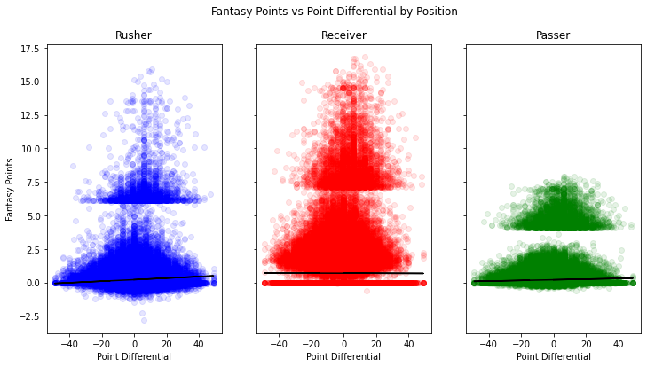

```python
fig, axs = plt.subplots(1, 3, figsize=(12, 6), sharey=True) # 1 row of 3 plots
fig.suptitle('Fantasy Points vs Point Differential by Position')
# Scatter plot with x = posteam_diff, y = fpts_rusher
axs[0].scatter(pbp['posteam_diff'], pbp['fpts_rusher'], color='blue', alpha=0.1)
# Add titles, labels
axs[0].set_title('Rusher')
axs[0].set_xlabel('Point Differential')
axs[0].set_ylabel('Fantasy Points')
# Calculate and plot line of best fit
a, b = np.polyfit(pbp['posteam_diff'], pbp['fpts_rusher'], 1)
axs[0].plot(pbp['posteam_diff'], pbp['posteam_diff']*a+b, color='black')

# Scatter plot with x = posteam_diff, y = fpts_receiver
axs[1].scatter(pbp['posteam_diff'], pbp['fpts_receiver'], color='red', alpha=0.1)
# Add titles, labels
axs[1].set_title('Receiver')
axs[1].set_xlabel('Point Differential')
# Calculate and plot line of best fit
a, b = np.polyfit(pbp['posteam_diff'], pbp['fpts_receiver'], 1)
axs[1].plot(pbp['posteam_diff'], pbp['posteam_diff']*a+b, color='black')

# Scatter plot with x = posteam_diff, y = fpts_passer
axs[2].scatter(pbp['posteam_diff'], pbp['fpts_passer'], color='green', alpha=0.1)
# Add titles, labels
axs[2].set_title('Passer')
axs[2].set_xlabel('Point Differential')
# Calculate and plot line of best fit
a, b = np.polyfit(pbp['posteam_diff'], pbp['fpts_passer'], 1)
axs[2].plot(pbp['posteam_diff'], pbp['posteam_diff']*a+b, color='black')
```

### 4.2 Fantasy Points Remaining vs Point Differential

Now, let's look a similar graph but for points remaining (what would be a perfectly accurate prediction) and point differential.

Same process as before with the scatterplots, but this time we will have it separated into wr1-3, rb1-2 and qb since that is what we have in our dataframe for points remaining.

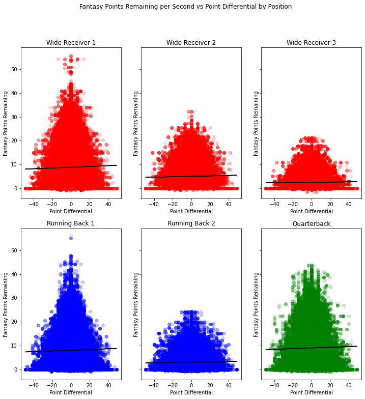

```python
fig, axs = plt.subplots(2, 3, figsize=(12, 12), sharey=True) # 2 rows of 3 plots
fig.suptitle('Fantasy Points Remaining per Second vs Point Differential by Position')

x = pbp['posteam_diff']
y = pbp['home_wr1_rem_pts']
axs[0][0].scatter(x, y, color='red', alpha=0.1)
# Set titles, labels
axs[0][0].set_title('Wide Receiver 1')
axs[0][0].set_xlabel('Point Differential')
axs[0][0].set_ylabel('Fantasy Points Remaining')
# Calculate and plot line of best fit
a, b = np.polyfit(x, y, 1)
axs[0][0].plot(x, x*a+b, color='black')

y = pbp['home_wr2_rem_pts']
axs[0][1].scatter(x, y, color='red', alpha=0.1)
# Set titles, labels
axs[0][1].set_title('Wide Receiver 2')
axs[0][1].set_xlabel('Point Differential')
axs[0][1].set_ylabel('Fantasy Points Remaining')
# Calculate and plot line of best fit
a, b = np.polyfit(x, y, 1)
axs[0][1].plot(x, x*a+b, color='black')

y = pbp['home_wr3_rem_pts']
axs[0][2].scatter(x, y, color='red', alpha=0.1)
# Set titles, labels
axs[0][2].set_title('Wide Receiver 3')
axs[0][2].set_xlabel('Point Differential')
axs[0][2].set_ylabel('Fantasy Points Remaining')
# Calculate and plot line of best fit
a, b = np.polyfit(x, y, 1)
axs[0][2].plot(x, x*a+b, color='black')

y = pbp['home_rb1_rem_pts']
axs[1][0].scatter(x, y, color='blue', alpha=0.1)
# Set titles, labels
axs[1][0].set_title('Running Back 1')
axs[1][0].set_xlabel('Point Differential')
axs[1][0].set_ylabel('Fantasy Points Remaining')
# Calculate and plot line of best fit
a, b = np.polyfit(x, y, 1)
axs[1][0].plot(x, x*a+b, color='black')

y = pbp['home_rb2_rem_pts']
axs[1][1].scatter(x, y, color='blue', alpha=0.1)
axs[1][1].set_title('Running Back 2')
axs[1][1].set_xlabel('Point Differential')
axs[1][1].set_ylabel('Fantasy Points Remaining')
# Calculate and plot line of best fit
a, b = np.polyfit(x, y, 1)
axs[1][1].plot(x, x*a+b, color='black')

y = pbp['home_qb_rem_pts']
axs[1][2].scatter(x, y, color='green', alpha=0.1)
# Set titles, labels
axs[1][2].set_title('Quarterback')
axs[1][2].set_xlabel('Point Differential')
axs[1][2].set_ylabel('Fantasy Points Remaining')
# Calculate and plot line of best fit
a, b = np.polyfit(x, y, 1)
axs[1][2].plot(x, x*a+b, color='black')
```

The lines of best fit seem to show slightly positive correlations for each position, with the most significant correlations seeming to be for wr1s, rb1s, and qbs. However, again these plots are such a mess that we can't take anything away for sure.

### 4.3 Fantasy Points vs Time Remaining

Let's step away from point differential for a minute and look at time remaining in the game. We will be using seaborn's lineplot function. More information is available here:

https://seaborn.pydata.org/generated/seaborn.lineplot.html

This plot is great for seeing correlations like this, since for each minute the function will plot the mean value for fantasy points as well as a confidence interval based on our data.

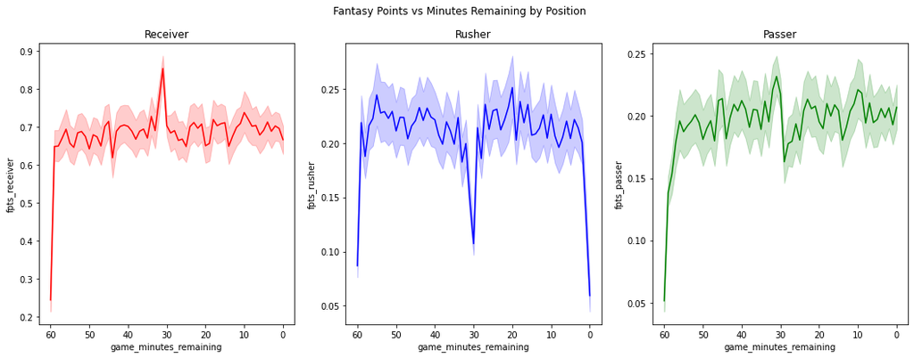

```python
fig, ax = plt.subplots(1, 3, figsize=(18, 6)) # 1 row of 3 plots
fig.suptitle('Fantasy Points vs Minutes Remaining by Position')

# Invert the x axis since it is time remaining, so the game goes from left to right
sns.lineplot(data=pbp, x='game_minutes_remaining', y='fpts_receiver', ax=ax[0], color='red').invert_xaxis()
ax[0].set_title('Receiver')
sns.lineplot(data=pbp, x='game_minutes_remaining', y='fpts_rusher', ax=ax[1], color='blue').invert_xaxis()
ax[1].set_title('Rusher')
sns.lineplot(data=pbp, x='game_minutes_remaining', y='fpts_passer', ax=ax[2], color='green').invert_xaxis()
ax[2].set_title('Passer')
plt.show()
```

Each graph looks pretty flat with anomalies at the beginning of the game, halftime and the end of the game. Unfortunately, again we cannot take much away from these plots. We're going to have to dig deeper to find some singificant takeaways.

### 4.4 Fantasy Points, Minutes Remaining, and Winning vs Losing

A commonly known trend in football games is that as time dwindles down, losing teams tend to pass more while winning teams tend to run more. This occurs because passing plays take less time than rushing plays, so in order to catch up, the losing team wants to minimize time wasted, and thus should pass more.

To see this, we are going to have to analyze the interaction of two independent variables: time remaining and game score. This is not possible on our previous 2-d plots, so we are going to add a third dimension by separating the plots into when the teams are losing vs when they are winning.

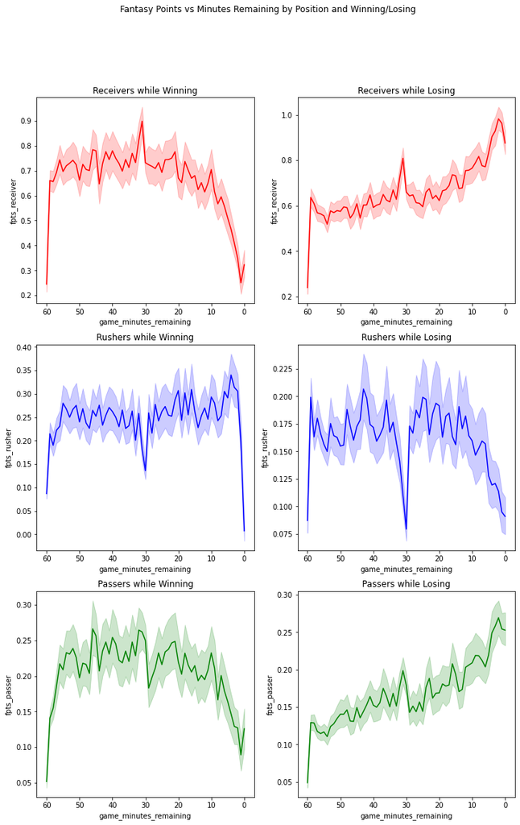

```python
fig, ax = plt.subplots(3, 2, figsize=(12, 18))
fig.suptitle('Fantasy Points vs Minutes Remaining by Position and Winning/Losing')

# Invert the x axis since it is time remaining, so the game goes from left to right
# Use pbp.loc[pbp['posteam_diff'] >= 0] to find when teams are winning
# >= because using > results in a very small sample size at the beginning of games,
# Since a team scoring very early does not happen often
sns.lineplot(data=pbp.loc[pbp['posteam_diff'] >= 0], x='game_minutes_remaining',
             y='fpts_receiver', ax=ax[0][0], color='red').invert_xaxis()
sns.lineplot(data=pbp.loc[pbp['posteam_diff'] >= 0], x='game_minutes_remaining',
             y='fpts_rusher', ax=ax[1][0], color='blue').invert_xaxis()
sns.lineplot(data=pbp.loc[pbp['posteam_diff'] >= 0], x='game_minutes_remaining',
             y='fpts_passer', ax=ax[2][0], color='green').invert_xaxis()
sns.lineplot(data=pbp.loc[pbp['posteam_diff'] <= 0], x='game_minutes_remaining',
             y='fpts_receiver', ax=ax[0][1], color='red').invert_xaxis()
sns.lineplot(data=pbp.loc[pbp['posteam_diff'] <= 0], x='game_minutes_remaining',
             y='fpts_rusher', ax=ax[1][1], color='blue').invert_xaxis()
sns.lineplot(data=pbp.loc[pbp['posteam_diff'] <= 0], x='game_minutes_remaining',
             y='fpts_passer', ax=ax[2][1], color='green').invert_xaxis()

# Add titles
ax[0][0].set_title('Receivers while Winning')
ax[0][1].set_title('Receivers while Losing')
ax[1][0].set_title('Rushers while Winning')
ax[1][1].set_title('Rushers while Losing')
ax[2][0].set_title('Passers while Winning')
ax[2][1].set_title('Passers while Losing')
plt.show()
```

Finally, a clear correlation! We can see clearly that as time remaining decreases:

- Receiving and passing fantasy points decrease for the winning team
- Receiving and passing fantasy points increase for the losing team
- Rushing fantasy points increase for the winning team
- Rushing fantasy points decrease for the losing team

It is important to note that these correlations are not linear, as the main difference only comes twoards the end of the game.

However, this insight should be enough for us to build a model to beat the current system that does not take this interaction into account.

Our model is likely to pick up other interactions between variables that are even more difficult to find through this basic data exploration.

## 5 Model Fitting

To evaluate our models, we will be using Mean Squared Error (MSE), which is equal to the mean of (predicted value - actual value)^2 over our test set. We have chosen mean squared error in order to harsly punish predictions that are very far off from the actual value. By minimizing MSE, we can feel confident that we have an improvement in accuracy.

In place of projections, we will using total points, since that represents perfectly accurate pregame predictions.

### 5.1 Wide Receivers

#### 5.1.1 Preparing Training and Test Sets

One last step before we can actually create our models, we need to divide our data into a training set and a test set. This is necessary because it would not be fair to test our model on data that it trained on. We will also split it up into x and y, where x is our input data, which is only what is available during the game. Y is the points remaining, which is what we are trying to predict with our projections.

```python
# Extract relevant columns for home_wr1 for train set (seasons up to 2020)
X_train_home_wr1 = pbp.loc[pbp['season'] < 2021,
      ['home_wr1_total_pts', 'home_pos', 'yardline_100',
        'game_seconds_remaining', 'home_diff']]
# Rename the total_pts column to more generic wr_total_pts
# This will allow us to concatenate it with the wr2 and wr3 data
X_train_home_wr1.rename(columns={'home_wr1_total_pts': 'wr_total_pts'}, inplace=True)
X_train_home_wr2 = pbp.loc[pbp['season'] < 2021,
      ['home_wr2_total_pts', 'home_pos', 'yardline_100',
        'game_seconds_remaining', 'home_diff']]
# Repeat for wr2, wr3
X_train_home_wr2.rename(columns={'home_wr2_total_pts': 'wr_total_pts'}, inplace=True)
X_train_home_wr3 = pbp.loc[pbp['season'] < 2021,
      ['home_wr3_total_pts', 'home_pos', 'yardline_100',
        'game_seconds_remaining', 'home_diff']]
X_train_home_wr3.rename(columns={'home_wr3_total_pts': 'wr_total_pts'}, inplace=True)

# Repeat for away wrs
X_train_away_wr1 = pbp.loc[pbp['season'] < 2021,
      ['away_wr1_total_pts', 'home_pos', 'yardline_100',
        'game_seconds_remaining', 'home_diff']]
X_train_away_wr1.rename(columns={'away_wr1_total_pts': 'wr_total_pts'}, inplace=True)
X_train_away_wr2 = pbp.loc[pbp['season'] < 2021,
      ['away_wr2_total_pts', 'home_pos', 'yardline_100',
        'game_seconds_remaining', 'home_diff']]
X_train_away_wr2.rename(columns={'away_wr2_total_pts': 'wr_total_pts'}, inplace=True)
X_train_away_wr3 = pbp.loc[pbp['season'] < 2021,
      ['away_wr3_total_pts', 'home_pos', 'yardline_100',
        'game_seconds_remaining', 'home_diff']]
X_train_away_wr3.rename(columns={'away_wr3_total_pts': 'wr_total_pts'}, inplace=True)

# Concatenate into home and away lists
X_train_home = pd.concat([X_train_home_wr1, X_train_home_wr2, X_train_home_wr3])
X_train_away = pd.concat([X_train_away_wr1, X_train_away_wr2, X_train_away_wr3])
# Invert home_pos and home_diff for away positions to make them consistent for
# all wrs in our training data
X_train_away['home_pos'] = X_train_away['home_pos']^1
X_train_away['home_diff'] = -X_train_away['home_diff']

# Concatenate to form our complete training data for wrs
X_train_wr = pd.concat([X_train_home, X_train_away])

# Similar process for the y values, but we only need one column
y_train_home = pd.concat([
    pbp.loc[pbp['season'] < 2021, 'home_wr1_rem_pts'],
    pbp.loc[pbp['season'] < 2021, 'home_wr2_rem_pts'],
    pbp.loc[pbp['season'] < 2021, 'home_wr3_rem_pts']])

y_train_away = pd.concat([
    pbp.loc[pbp['season'] < 2021, 'away_wr1_rem_pts'],
    pbp.loc[pbp['season'] < 2021, 'away_wr2_rem_pts'],
    pbp.loc[pbp['season'] < 2021, 'away_wr3_rem_pts']])

y_train_wr = pd.concat([y_train_home, y_train_away])

# Same process for test set, but for season = 2021
X_test_home_wr1 = pbp.loc[pbp['season'] == 2021,
      ['home_wr1_total_pts', 'home_pos', 'yardline_100',
        'game_seconds_remaining', 'home_diff']]
X_test_home_wr1.rename(columns={'home_wr1_total_pts': 'wr_total_pts'}, inplace=True)
X_test_home_wr2 = pbp.loc[pbp['season'] == 2021,
      ['home_wr2_total_pts', 'home_pos', 'yardline_100',
        'game_seconds_remaining', 'home_diff']]
X_test_home_wr2.rename(columns={'home_wr2_total_pts': 'wr_total_pts'}, inplace=True)
X_test_home_wr3 = pbp.loc[pbp['season'] == 2021,
      ['home_wr3_total_pts', 'home_pos', 'yardline_100',
        'game_seconds_remaining', 'home_diff']]
X_test_home_wr3.rename(columns={'home_wr3_total_pts': 'wr_total_pts'}, inplace=True)

X_test_away_wr1 = pbp.loc[pbp['season'] == 2021,
      ['away_wr1_total_pts', 'home_pos', 'yardline_100',
        'game_seconds_remaining', 'home_diff']]
X_test_away_wr1.rename(columns={'away_wr1_total_pts': 'wr_total_pts'}, inplace=True)
X_test_away_wr2 = pbp.loc[pbp['season'] == 2021,
      ['away_wr2_total_pts', 'home_pos', 'yardline_100',
        'game_seconds_remaining', 'home_diff']]
X_test_away_wr2.rename(columns={'away_wr2_total_pts': 'wr_total_pts'}, inplace=True)
X_test_away_wr3 = pbp.loc[pbp['season'] == 2021,
      ['away_wr3_total_pts', 'home_pos', 'yardline_100',
        'game_seconds_remaining', 'home_diff']]
X_test_away_wr3.rename(columns={'away_wr3_total_pts': 'wr_total_pts'}, inplace=True)

X_test_home = pd.concat([X_test_home_wr1, X_test_home_wr2, X_test_home_wr3])
X_test_away = pd.concat([X_test_away_wr1, X_test_away_wr2, X_test_away_wr3])
X_test_away['home_pos'] = X_test_away['home_pos']^1
X_test_away['home_diff'] = -X_test_away['home_diff']

X_test_wr = pd.concat([X_test_home, X_test_away])

y_test_home = pd.concat([
    pbp.loc[pbp['season'] == 2021, 'home_wr1_rem_pts'],
    pbp.loc[pbp['season'] == 2021, 'home_wr2_rem_pts'],
    pbp.loc[pbp['season'] == 2021, 'home_wr3_rem_pts']])

y_test_away = pd.concat([
    pbp.loc[pbp['season'] == 2021, 'away_wr1_rem_pts'],
    pbp.loc[pbp['season'] == 2021, 'away_wr2_rem_pts'],
    pbp.loc[pbp['season'] == 2021, 'away_wr3_rem_pts']])

y_test_wr = pd.concat([y_test_home, y_test_away])
```

#### 5.1.2 Current Model

Let's first calculate our baseline of the current projections model.

The current model is simply: projected points * (time remaining / total game time)

```python
# MSE = mean((actual - projected)^2)
mse = ((y_test_wr - X_test_wr['wr_total_pts'] * (X_test_wr['game_seconds_remaining'] / 3600))**2).mean()
print(f'MSE = {mse}')
```

```
MSE = 8.639789613326784
```

#### 5.1.3 K-Nearest Neighbor

The first model we will try is a regression model called k-nearest neighbor. More information can be found about it here:

https://scikit-learn.org/stable/modules/neighbors.html#regression

It takes a hyperparameter of n, which is the number of close points that it will take into account when making its prediction. Let's try a few different values of n and combine their MSE to find a sweet spot for the parameter.

```python
for n in [5, 10, 20, 50]:
  # Create Knn object with appropriate value for n
  knn = neighbors.KNeighborsRegressor(n_neighbors = n)
  # Fit model
  knn.fit(X_train_wr, y_train_wr)

  # Use model projection to calculate MSE on our test set
  mse = ((knn.predict(X_test_wr) - y_test_wr)**2).mean()
  print(f'MSE for n={n}: {mse}')
```

```
MSE for n=5: 9.156399697892903
MSE for n=10: 8.4660452326216
MSE for n=20: 8.211178668815393
MSE for n=50: 8.324530750300902
```

Looks like n=20 is a good bet for this model, and we can see that it did indeed improve on the MSE of the base model. However, I think we can do better. Let's try another regression model.

#### 5.1.4 Decision Tree Regressor

Another popular model is a decision tree regressor, which you can read about here:

https://scikit-learn.org/stable/modules/tree.html#tree

Let's see what it can manage for our data.

```python
# Create regressor object random_state to ensure consitent results
dtr = DecisionTreeRegressor(random_state = 0)
# Fit model
dtr.fit(X_train_wr, y_train_wr)

# Use model projection to calculate MSE on our test set
mse = ((dtr.predict(X_test_wr) - y_test_wr)**2).mean()
print(f'MSE = {mse}')
```

```
MSE = 14.823069889897978
```

That's much worse than the current system! Not much more to say than that. Let's move on to another model.

#### 5.1.5 Linear Regression with Interaction Terms

For our next model, we will use another package called statsmodels, which provides a function called ols, which allows us to perform a linear regression with whichever terms we choose. Here we are going to use all possible interaction terms between our columns. To accomplish this, we will use an R-style formula in our method call. As the number of columns increases, these interactions can get out of hand very quickly. However, since we are only analyzing 5 columns, it is still reasonable to look at all of the interactions.

Read more about:

- OLS: https://www.statsmodels.org/dev/generated/statsmodels.formula.api.ols.html
- R-style formulas: https://www.statsmodels.org/dev/example_formulas.html

```python
# combine x and y into one dataframe
train_wr = pd.concat([X_train_wr, y_train_wr], axis=1)
# Need to rename our y column since it was concatenated as an array and thus
# received a default label of 0
train_wr.rename(columns={0: 'wr_rem_pts'}, inplace=True)
# Fit model
wr_ols = smf.ols(formula='wr_rem_pts ~ wr_total_pts * home_pos * game_seconds_remaining * yardline_100 * home_diff', data=train_wr).fit()
print(wr_ols.summary())

# Use model projection to calculate MSE on our test set
mse = ((wr_ols.predict(X_test_wr) - y_test_wr)**2).mean()
print(f'MSE = {mse}')
```

```
                            OLS Regression Results
==============================================================================
Dep. Variable:             wr_rem_pts   R-squared:                       0.805
Model:                            OLS   Adj. R-squared:                  0.805
Method:                 Least Squares   F-statistic:                 1.681e+05
Date:                Thu, 15 Dec 2022   Prob (F-statistic):               0.00
Time:                        22:04:49   Log-Likelihood:            -3.0573e+06
No. Observations:             1258878   AIC:                         6.115e+06
Df Residuals:                 1258846   BIC:                         6.115e+06
Df Model:                          31
Covariance Type:            nonrobust
=======================================================================================================================================
                                                                          coef    std err          t      P>|t|      [0.025      0.975]
---------------------------------------------------------------------------------------------------------------------------------------
Intercept                                                              -0.2294      0.026     -8.879      0.000      -0.280      -0.179
wr_total_pts                                                            0.0699      0.002     35.862      0.000       0.066       0.074
home_pos                                                               -0.0773      0.037     -2.102      0.036      -0.149      -0.005
wr_total_pts:home_pos                                                  -0.0375      0.003    -13.731      0.000      -0.043      -0.032
game_seconds_remaining                                               9.103e-05   1.31e-05      6.926      0.000    6.53e-05       0.000
wr_total_pts:game_seconds_remaining                                     0.0003   9.89e-07    275.840      0.000       0.000       0.000
home_pos:game_seconds_remaining                                     -7.576e-05   1.87e-05     -4.061      0.000      -0.000   -3.92e-05
wr_total_pts:home_pos:game_seconds_remaining                        -6.647e-06   1.38e-06     -4.806      0.000   -9.36e-06   -3.94e-06
yardline_100                                                            0.0006      0.000      1.247      0.213      -0.000       0.002
wr_total_pts:yardline_100                                              -0.0006   3.65e-05    -16.072      0.000      -0.001      -0.001
home_pos:yardline_100                                                   0.0013      0.001      1.937      0.053   -1.57e-05       0.003
wr_total_pts:home_pos:yardline_100                                      0.0008   5.11e-05     15.675      0.000       0.001       0.001
game_seconds_remaining:yardline_100                                 -8.166e-07   2.39e-07     -3.413      0.001   -1.29e-06   -3.48e-07
wr_total_pts:game_seconds_remaining:yardline_100                     1.065e-07   1.81e-08      5.884      0.000     7.1e-08    1.42e-07
home_pos:game_seconds_remaining:yardline_100                         1.006e-06   3.39e-07      2.968      0.003    3.42e-07    1.67e-06
wr_total_pts:home_pos:game_seconds_remaining:yardline_100           -4.669e-08   2.54e-08     -1.841      0.066   -9.64e-08    3.02e-09
home_diff                                                               0.0124      0.002      5.790      0.000       0.008       0.017
wr_total_pts:home_diff                                                 -0.0053      0.000    -32.233      0.000      -0.006      -0.005
home_pos:home_diff                                                     -0.0017      0.003     -0.541      0.589      -0.008       0.004
wr_total_pts:home_pos:home_diff                                         0.0008      0.000      3.431      0.001       0.000       0.001
game_seconds_remaining:home_diff                                    -1.543e-06   1.53e-06     -1.009      0.313   -4.54e-06    1.46e-06
wr_total_pts:game_seconds_remaining:home_diff                       -2.157e-06   1.15e-07    -18.731      0.000   -2.38e-06   -1.93e-06
home_pos:game_seconds_remaining:home_diff                            3.633e-06   2.17e-06      1.673      0.094   -6.23e-07    7.89e-06
wr_total_pts:home_pos:game_seconds_remaining:home_diff              -6.358e-07    1.6e-07     -3.962      0.000    -9.5e-07   -3.21e-07
```

[output cut: 20 more lines]

The summary features prints out a ton of information about our model, so let's focus on some highlights:

- This is far more linear regression terms than normal, but it is helpful here because it allows the algorithm to identify correlations that we might not see through typical data exploration.
- You can see which interaction terms we are confident about a relationship in by the column p > |t|, which is more or less the probability of a significant correlation between that interaction and our results.
- We have an R-squared value of 0.805, which is not enough for us to say that the correlation is decidedly linear, but it is certainly high for a dataset that on first glance does not seem very linear at all.
- Our MSE on the test set is 7.477, which is a huge improvement on the base predictions!
- There is a warning on the bottom about multicollinearity. It is likely that this is due to our interaction terms, but let's run a test to make sure none of our initial columns are at fault.

To do this, we will make a heatmap for pairwise correlation coefficient of our columns.

Read more about:

- multicollinearity: https://statisticsbyjim.com/regression/multicollinearity-in-regression-analysis/
- this visualization: https://medium.com/@szabo.bibor/how-to-create-a-seaborn-correlation-heatmap-in-python-834c0686b88e

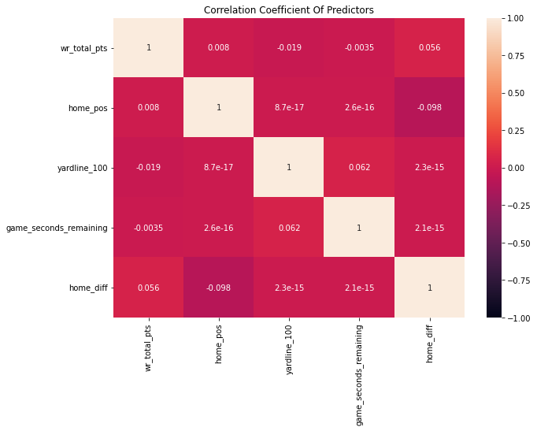

```python
plt.figure(figsize=(10,7))

# Create heatmap
sns.heatmap(X_train_wr.corr(), annot=True, vmin=-1, vmax=1)
plt.title('Correlation Coefficient Of Predictors')
plt.show()
```

None of the values are close to -1 or 1, so we are safe to proceed without any further data manipulation.

Next let's plot the distribution of the residuals for our model and the base model and see if we can gain any insights.

Here we'll use another key matplotlib plot: the histogram: https://matplotlib.org/stable/api/_as_gen/matplotlib.pyplot.hist.html

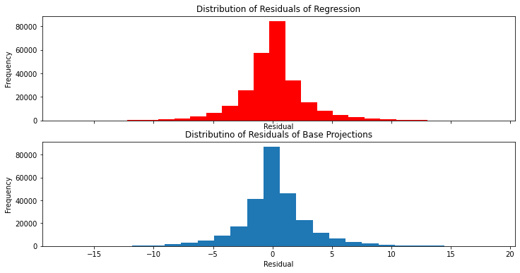

```python
fig, ax = plt.subplots(2, 1, figsize=(12, 6), sharex=True) # 1 column of two plots
# Histogram of residuals from OLS with 25 bins
ax[0].hist(y_test_wr - wr_ols.predict(X_test_wr), bins=25, color='red')
# Set title, labels
ax[0].set_title('Distribution of Residuals of Regression')
ax[0].set_ylabel('Frequency')
ax[0].set_xlabel('Residual')

# Histogram of residuals from OLS with 25 bins
ax[1].hist(y_test_wr - X_test_wr['wr_total_pts'] * (X_test_wr['game_seconds_remaining'] / 3600), bins=25)
# Set title, labels
ax[1].set_title('Distributino of Residuals of Base Projections')
ax[1].set_ylabel('Frequency')
ax[1].set_xlabel('Residual')

plt.show()
```

Both residual plots look fairly normally distributed, indicating our choice of model is reasonable.

#### 5.1.6 Hypothesis Test

Our mean squared error seamed significantly better, but let's run a statistical test to ensure that the difference was statistically significant. To do this, we'll use the t test function another key Python library: scipy. We are using a t test since we want to compare the sample mean squared errors from our test data.

```python
# Make list of residuals from OLS
ols_errors = y_test_wr - wr_ols.predict(X_test_wr)
# Make list of residuals from base projection model
base_errors = y_test_wr - X_test_wr['wr_total_pts'] * (X_test_wr['game_seconds_remaining'] / 3600)
# Perform a t-test for the above lists squared
stats.ttest_ind(ols_errors**2, base_errors**2)
```

```
Ttest_indResult(statistic=-22.624864341469962, pvalue=2.7956032430211804e-113)
```

A p-value that small eliminates all doubt that we were successful in creating a new model for in-game fantasy projections.

**The following sections will be replicas of the previous process with respect to running backs and quarterbacks (Spoilers: similarly successful results). If you are not interested in this, skip to the conclusion.**

### 5.2 Running Backs

#### 5.2.1 Preparing Training and Test Sets

One last step before we can actually create our models, we need to divide our data into a training set and a test set. This is necessary because it would not be fair to test our model on data that it trained on. We will also split it up into x and y, where x is our input data, which is only what is available during the game. Y is the points remaining, which is what we are trying to predict with our projections.

```python
# This is the same exact process we did with the wrs above, but with only two rbs per team
X_train_home_rb1 = pbp.loc[pbp['season'] == 2020,
      ['home_rb1_total_pts', 'home_pos', 'yardline_100',
        'game_seconds_remaining', 'home_diff']]
X_train_home_rb1.rename(columns={'home_rb1_total_pts': 'rb_total_pts'}, inplace=True)
X_train_home_rb2 = pbp.loc[pbp['season'] == 2020,
      ['home_rb2_total_pts', 'home_pos', 'yardline_100',
        'game_seconds_remaining', 'home_diff']]
X_train_home_rb2.rename(columns={'home_rb2_total_pts': 'rb_total_pts'}, inplace=True)

X_train_away_rb1 = pbp.loc[pbp['season'] == 2020,
      ['away_rb1_total_pts', 'home_pos', 'yardline_100',
        'game_seconds_remaining', 'home_diff']]
X_train_away_rb1.rename(columns={'away_rb1_total_pts': 'rb_total_pts'}, inplace=True)
X_train_away_rb2 = pbp.loc[pbp['season'] == 2020,
      ['away_rb2_total_pts', 'home_pos', 'yardline_100',
        'game_seconds_remaining', 'home_diff']]
X_train_away_rb2.rename(columns={'away_rb2_total_pts': 'rb_total_pts'}, inplace=True)

X_train_home = pd.concat([X_train_home_rb1, X_train_home_rb2])
X_train_away = pd.concat([X_train_away_rb1, X_train_away_rb2])
X_train_away['home_pos'] = X_train_away['home_pos']^1
X_train_away['home_diff'] = -X_train_away['home_diff']

X_train_rb = pd.concat([X_train_home, X_train_away])

y_train_home = pd.concat([
    pbp.loc[pbp['season'] == 2020, 'home_rb1_rem_pts'],
    pbp.loc[pbp['season'] == 2020, 'home_rb2_rem_pts']])

y_train_away = pd.concat([
    pbp.loc[pbp['season'] == 2020, 'away_rb1_rem_pts'],
    pbp.loc[pbp['season'] == 2020, 'away_rb2_rem_pts']])

y_train_rb = pd.concat([y_train_home, y_train_away])

X_test_home_rb1 = pbp.loc[pbp['season'] == 2021,
      ['home_rb1_total_pts', 'home_pos', 'yardline_100',
        'game_seconds_remaining', 'home_diff']]
X_test_home_rb1.rename(columns={'home_rb1_total_pts': 'rb_total_pts'}, inplace=True)
X_test_home_rb2 = pbp.loc[pbp['season'] == 2021,
      ['home_rb2_total_pts', 'home_pos', 'yardline_100',
        'game_seconds_remaining', 'home_diff']]
X_test_home_rb2.rename(columns={'home_rb2_total_pts': 'rb_total_pts'}, inplace=True)

X_test_away_rb1 = pbp.loc[pbp['season'] == 2021,
      ['away_rb1_total_pts', 'home_pos', 'yardline_100',
        'game_seconds_remaining', 'home_diff']]
X_test_away_rb1.rename(columns={'away_rb1_total_pts': 'rb_total_pts'}, inplace=True)
X_test_away_rb2 = pbp.loc[pbp['season'] == 2021,
      ['away_rb2_total_pts', 'home_pos', 'yardline_100',
        'game_seconds_remaining', 'home_diff']]
X_test_away_rb2.rename(columns={'away_rb2_total_pts': 'rb_total_pts'}, inplace=True)

X_test_home = pd.concat([X_test_home_rb1, X_test_home_rb2])
X_test_away = pd.concat([X_test_away_rb1, X_test_away_rb2])
X_test_away['home_pos'] = X_test_away['home_pos']^1
X_test_away['home_diff'] = -X_test_away['home_diff']

X_test_rb = pd.concat([X_test_home, X_test_away])

y_test_home = pd.concat([
    pbp.loc[pbp['season'] == 2021, 'home_rb1_rem_pts'],
    pbp.loc[pbp['season'] == 2021, 'home_rb2_rem_pts']])

y_test_away = pd.concat([
    pbp.loc[pbp['season'] == 2021, 'away_rb1_rem_pts'],
    pbp.loc[pbp['season'] == 2021, 'away_rb2_rem_pts']])

y_test_rb = pd.concat([y_test_home, y_test_away])
```

#### 5.2.2 Current Model

Let's first calculate our baseline of the current projections model.

The current model is simply: projected points * (time remaining / total game time)

```python
# Same process as above but for rbs
mse = ((y_test_rb - X_test_rb['rb_total_pts'] * (X_test_rb['game_seconds_remaining'] / 3600))**2).mean()
print(f'MSE = {mse}')
```

```
MSE = 6.95247394219868
```

#### 5.2.3 Linear Regression with Interaction Terms

For our next model, we will use another package called statsmodels, which provides a function called ols, which allows us to perform a linear regression with whichever terms we choose. Here we are going to use all possible interaction terms between our columns. To accomplish this, we will use an R-style formula in our method call. As the number of columns increases, these interactions can get out of hand very quickly. However, since we are only analyzing 5 columns, it is still reasonable to look at all of the interactions.

Read more about:

- OLS: https://www.statsmodels.org/dev/generated/statsmodels.formula.api.ols.html
- R-style formulas: https://www.statsmodels.org/dev/example_formulas.html

```python
# Same process as above but for rbs
train_rb = pd.concat([X_train_rb, y_train_rb], axis=1)
train_rb.rename(columns={0: 'rb_rem_pts'}, inplace=True)
rb_ols = smf.ols(formula='rb_rem_pts ~ rb_total_pts * home_pos * game_seconds_remaining * yardline_100 * home_diff', data=train_rb).fit()
print(rb_ols.summary())

mse = ((rb_ols.predict(X_test_rb) - y_test_rb)**2).mean()
print(f'MSE = {mse}')
```

```
                            OLS Regression Results
==============================================================================
Dep. Variable:             rb_rem_pts   R-squared:                       0.835
Model:                            OLS   Adj. R-squared:                  0.835
Method:                 Least Squares   F-statistic:                 2.740e+04
Date:                Thu, 15 Dec 2022   Prob (F-statistic):               0.00
Time:                        22:04:53   Log-Likelihood:            -3.9494e+05
No. Observations:              168184   AIC:                         7.899e+05
Df Residuals:                  168152   BIC:                         7.903e+05
Df Model:                          31
Covariance Type:            nonrobust
=======================================================================================================================================
                                                                          coef    std err          t      P>|t|      [0.025      0.975]
---------------------------------------------------------------------------------------------------------------------------------------
Intercept                                                              -0.0525      0.062     -0.848      0.397      -0.174       0.069
rb_total_pts                                                            0.0482      0.005     10.240      0.000       0.039       0.057
home_pos                                                               -0.0477      0.089     -0.535      0.593      -0.223       0.127
rb_total_pts:home_pos                                                  -0.0087      0.007     -1.322      0.186      -0.022       0.004
game_seconds_remaining                                              -2.498e-05   3.15e-05     -0.793      0.428   -8.67e-05    3.68e-05
rb_total_pts:game_seconds_remaining                                     0.0003   2.37e-06    119.377      0.000       0.000       0.000
home_pos:game_seconds_remaining                                      -8.83e-06   4.53e-05     -0.195      0.845   -9.76e-05    7.99e-05
rb_total_pts:home_pos:game_seconds_remaining                        -1.555e-05   3.33e-06     -4.674      0.000   -2.21e-05   -9.03e-06
yardline_100                                                           -0.0019      0.001     -1.591      0.112      -0.004       0.000
rb_total_pts:yardline_100                                              -0.0003   9.16e-05     -2.745      0.006      -0.000   -7.19e-05
home_pos:yardline_100                                                   0.0009      0.002      0.518      0.604      -0.002       0.004
rb_total_pts:home_pos:yardline_100                                      0.0004      0.000      3.072      0.002       0.000       0.001
game_seconds_remaining:yardline_100                                  7.741e-07   5.91e-07      1.310      0.190   -3.84e-07    1.93e-06
rb_total_pts:game_seconds_remaining:yardline_100                    -5.588e-08   4.49e-08     -1.244      0.214   -1.44e-07    3.22e-08
home_pos:game_seconds_remaining:yardline_100                        -5.757e-08   8.46e-07     -0.068      0.946   -1.71e-06     1.6e-06
rb_total_pts:home_pos:game_seconds_remaining:yardline_100            1.128e-07   6.31e-08      1.788      0.074   -1.09e-08    2.36e-07
home_diff                                                              -0.0103      0.005     -1.909      0.056      -0.021       0.000
rb_total_pts:home_diff                                                  0.0002      0.000      0.412      0.680      -0.001       0.001
home_pos:home_diff                                                      0.0162      0.008      2.075      0.038       0.001       0.032
rb_total_pts:home_pos:home_diff                                        -0.0019      0.001     -3.324      0.001      -0.003      -0.001
game_seconds_remaining:home_diff                                     6.814e-06   3.82e-06      1.784      0.074    -6.7e-07    1.43e-05
rb_total_pts:game_seconds_remaining:home_diff                        -3.22e-06   2.87e-07    -11.217      0.000   -3.78e-06   -2.66e-06
home_pos:game_seconds_remaining:home_diff                            2.659e-06   5.48e-06      0.485      0.628   -8.08e-06    1.34e-05
rb_total_pts:home_pos:game_seconds_remaining:home_diff               -5.82e-08   4.06e-07     -0.143      0.886   -8.55e-07    7.38e-07
```

[output cut: 20 more lines]

Next let's plot the distribution of the residuals for our model and the base model and see if we can gain any insights.

Here we'll use another key matplotlib plot: the histogram: https://matplotlib.org/stable/api/_as_gen/matplotlib.pyplot.hist.html

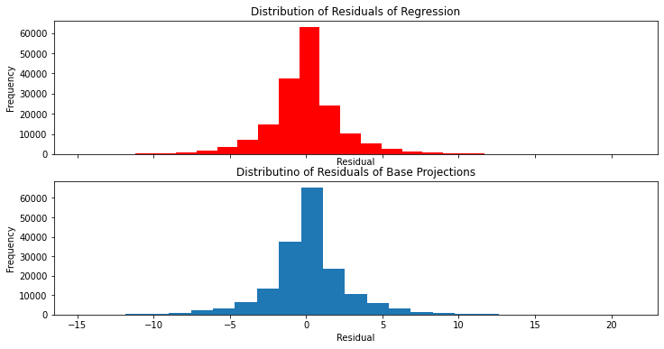

```python
# Same process as above but for rbs
fig, ax = plt.subplots(2, 1, figsize=(12, 6), sharex=True)
ax[0].hist(y_test_rb - rb_ols.predict(X_test_rb), bins=25, color='red')
ax[0].set_title('Distribution of Residuals of Regression')
ax[0].set_ylabel('Frequency')
ax[0].set_xlabel('Residual')
ax[1].hist(y_test_rb - X_test_rb['rb_total_pts'] * (X_test_rb['game_seconds_remaining'] / 3600), bins=25)
ax[1].set_title('Distributino of Residuals of Base Projections')
ax[1].set_ylabel('Frequency')
ax[1].set_xlabel('Residual')

plt.show()
```

Both residual plots look fairly normally distributed, indicating our choice of model is reasonable.

#### 5.2.4 Hypothesis Test

Our mean squared error seamed significantly better, but let's run a statistical test to ensure that the difference was statistically significant. To do this, we'll use the t test function another key Python library: scipy. We are using a t test since we want to compare the sample mean squared errors from our test data.

```python
# Same process as above but for rbs
ols_errors = y_test_rb - rb_ols.predict(X_test_rb)
base_errors = y_test_rb - X_test_rb['rb_total_pts'] * (X_test_rb['game_seconds_remaining'] / 3600)
stats.ttest_ind(ols_errors**2, base_errors**2)
```

```
Ttest_indResult(statistic=-15.574797913518285, pvalue=1.1265796067493718e-54)
```

A p-value that small eliminates all doubt that we were successful in creating a new model for in-game fantasy projections.

**The following section will be a replica of the previous process with respect to quarterbacks (Spoilers: similarly successful results). If you are not interested in this, skip to the conclusion.**

### 5.3 Quarterback

#### 5.3.1 Preparing Training and Test Sets

One last step before we can actually create our models, we need to divide our data into a training set and a test set. This is necessary because it would not be fair to test our model on data that it trained on. We will also split it up into x and y, where x is our input data, which is only what is available during the game. Y is the points remaining, which is what we are trying to predict with our projections.

```python
# Once more, same proess as above, but for qbs and we only have one per team
X_train_home_qb = pbp.loc[pbp['season'] == 2020,
      ['home_qb_total_pts', 'home_pos', 'yardline_100',
        'game_seconds_remaining', 'home_diff']]
X_train_home_qb.rename(columns={'home_qb_total_pts': 'qb_total_pts'}, inplace=True)

X_train_away_qb = pbp.loc[pbp['season'] == 2020,
      ['away_qb_total_pts', 'home_pos', 'yardline_100',
        'game_seconds_remaining', 'home_diff']]
X_train_away_qb.rename(columns={'away_qb_total_pts': 'qb_total_pts'}, inplace=True)

X_train_away_qb['home_pos'] = X_train_away_qb['home_pos']^1
X_train_away_qb['home_diff'] = -X_train_away_qb['home_diff']

X_train_qb = pd.concat([X_train_home_qb, X_train_away_qb])

y_train_home = pbp.loc[pbp['season'] == 2020, 'home_qb_rem_pts']

y_train_away = pbp.loc[pbp['season'] == 2020, 'away_qb_rem_pts']

y_train_qb = pd.concat([y_train_home, y_train_away])

X_test_home_qb = pbp.loc[pbp['season'] == 2021,
      ['home_qb_total_pts', 'home_pos', 'yardline_100',
        'game_seconds_remaining', 'home_diff']]
X_test_home_qb.rename(columns={'home_qb_total_pts': 'qb_total_pts'}, inplace=True)

X_test_away_qb = pbp.loc[pbp['season'] == 2021,
      ['away_qb_total_pts', 'home_pos', 'yardline_100',
        'game_seconds_remaining', 'home_diff']]
X_test_away_qb.rename(columns={'away_qb_total_pts': 'qb_total_pts'}, inplace=True)

X_test_away_qb['home_pos'] = X_test_away_qb['home_pos']^1
X_test_away_qb['home_diff'] = -X_test_away_qb['home_diff']

X_test_qb = pd.concat([X_test_home_qb, X_test_away_qb])

y_test_home = pbp.loc[pbp['season'] == 2021, 'home_qb_rem_pts']

y_test_away = pbp.loc[pbp['season'] == 2021, 'away_qb_rem_pts']

y_test_qb = pd.concat([y_test_home, y_test_away])
```

#### 5.3.2 Current Model

Let's first calculate our baseline of the current projections model.

The current model is simply: projected points * (time remaining / total game time)

```python
# Same process as above but for qbs
mse = ((y_test_qb - X_test_qb['qb_total_pts'] * (X_test_qb['game_seconds_remaining'] / 3600))**2).mean()
print(f'MSE = {mse}')
```

```
MSE = 9.900581206495328
```

#### 5.3.3 Linear Regression with Interaction Terms

For our next model, we will use another package called statsmodels, which provides a function called ols, which allows us to perform a linear regression with whichever terms we choose. Here we are going to use all possible interaction terms between our columns. To accomplish this, we will use an R-style formula in our method call. As the number of columns increases, these interactions can get out of hand very quickly. However, since we are only analyzing 5 columns, it is still reasonable to look at all of the interactions.

Read more about:

- OLS: https://www.statsmodels.org/dev/generated/statsmodels.formula.api.ols.html
- R-style formulas: https://www.statsmodels.org/dev/example_formulas.html

```python
# Same process as above but for qbs
train_qb = pd.concat([X_train_qb, y_train_qb], axis=1)
train_qb.rename(columns={0: 'qb_rem_pts'}, inplace=True)
qb_ols = smf.ols(formula='qb_rem_pts ~ qb_total_pts * home_pos * game_seconds_remaining * yardline_100 * home_diff', data=train_qb).fit()
print(qb_ols.summary())

mse = ((qb_ols.predict(X_test_qb) - y_test_qb)**2).mean()
print(f'MSE = {mse}')
```

```
                            OLS Regression Results
==============================================================================
Dep. Variable:             qb_rem_pts   R-squared:                       0.901
Model:                            OLS   Adj. R-squared:                  0.901
Method:                 Least Squares   F-statistic:                 2.470e+04
Date:                Thu, 15 Dec 2022   Prob (F-statistic):               0.00
Time:                        22:04:55   Log-Likelihood:            -1.9868e+05
No. Observations:               84092   AIC:                         3.974e+05
Df Residuals:                   84060   BIC:                         3.977e+05
Df Model:                          31
Covariance Type:            nonrobust
=======================================================================================================================================
                                                                          coef    std err          t      P>|t|      [0.025      0.975]
---------------------------------------------------------------------------------------------------------------------------------------
Intercept                                                              -1.2025      0.130     -9.262      0.000      -1.457      -0.948
qb_total_pts                                                            0.1112      0.006     17.650      0.000       0.099       0.124
home_pos                                                                0.4306      0.185      2.333      0.020       0.069       0.792
qb_total_pts:home_pos                                                  -0.0428      0.009     -4.892      0.000      -0.060      -0.026
game_seconds_remaining                                                  0.0003   6.47e-05      4.329      0.000       0.000       0.000
qb_total_pts:game_seconds_remaining                                     0.0003   3.13e-06     84.671      0.000       0.000       0.000
home_pos:game_seconds_remaining                                        -0.0002   9.23e-05     -2.518      0.012      -0.000   -5.15e-05
qb_total_pts:home_pos:game_seconds_remaining                        -6.195e-07   4.38e-06     -0.141      0.888   -9.21e-06    7.97e-06
yardline_100                                                            0.0049      0.002      2.019      0.043       0.000       0.010
qb_total_pts:yardline_100                                              -0.0008      0.000     -6.491      0.000      -0.001      -0.001
home_pos:yardline_100                                                  -0.0072      0.003     -2.075      0.038      -0.014      -0.000
qb_total_pts:home_pos:yardline_100                                      0.0010      0.000      5.936      0.000       0.001       0.001
game_seconds_remaining:yardline_100                                  -1.25e-06   1.19e-06     -1.055      0.291   -3.57e-06    1.07e-06
qb_total_pts:game_seconds_remaining:yardline_100                     1.301e-07   5.83e-08      2.231      0.026    1.58e-08    2.44e-07
home_pos:game_seconds_remaining:yardline_100                         3.717e-06    1.7e-06      2.187      0.029    3.86e-07    7.05e-06
qb_total_pts:home_pos:game_seconds_remaining:yardline_100           -1.731e-07   8.21e-08     -2.110      0.035   -3.34e-07   -1.23e-08
home_diff                                                               0.0860      0.010      8.473      0.000       0.066       0.106
qb_total_pts:home_diff                                                 -0.0099      0.001    -19.522      0.000      -0.011      -0.009
home_pos:home_diff                                                     -0.0464      0.015     -3.188      0.001      -0.075      -0.018
qb_total_pts:home_pos:home_diff                                         0.0028      0.001      3.900      0.000       0.001       0.004
game_seconds_remaining:home_diff                                    -5.051e-05   7.23e-06     -6.983      0.000   -6.47e-05   -3.63e-05
qb_total_pts:game_seconds_remaining:home_diff                       -1.654e-07   3.45e-07     -0.480      0.632   -8.41e-07    5.11e-07
home_pos:game_seconds_remaining:home_diff                             4.23e-05   1.03e-05      4.103      0.000    2.21e-05    6.25e-05
qb_total_pts:home_pos:game_seconds_remaining:home_diff              -2.727e-06   4.85e-07     -5.619      0.000   -3.68e-06   -1.78e-06
```

[output cut: 20 more lines]

Next let's plot the distribution of the residuals for our model and the base model and see if we can gain any insights.

Here we'll use another key matplotlib plot: the histogram: https://matplotlib.org/stable/api/_as_gen/matplotlib.pyplot.hist.html

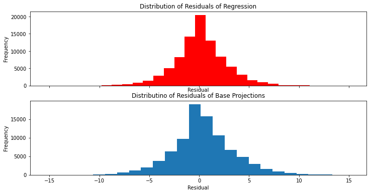

```python
# Same process as above but for qbs
fig, ax = plt.subplots(2, 1, figsize=(12, 6), sharex=True)
ax[0].hist(y_test_qb - qb_ols.predict(X_test_qb), bins=25, color='red')
ax[0].set_title('Distribution of Residuals of Regression')
ax[0].set_ylabel('Frequency')
ax[0].set_xlabel('Residual')
ax[1].hist(y_test_qb - X_test_qb['qb_total_pts'] * (X_test_qb['game_seconds_remaining'] / 3600), bins=25)
ax[1].set_title('Distributino of Residuals of Base Projections')
ax[1].set_ylabel('Frequency')
ax[1].set_xlabel('Residual')

plt.show()
```

Both residual plots look fairly normally distributed, indicating our choice of model is reasonable.

#### 5.3.4 Hypothesis Test

Our mean squared error seamed significantly better, but let's run a statistical test to ensure that the difference was statistically significant. To do this, we'll use the t test function another key Python library: scipy. We are using a t test since we want to compare the sample mean squared errors from our test data.

```python
# Same process as above but for qbs
ols_errors = y_test_qb - qb_ols.predict(X_test_qb)
base_errors = y_test_qb - X_test_qb['qb_total_pts'] * (X_test_qb['game_seconds_remaining'] / 3600)
stats.ttest_ind(ols_errors**2, base_errors**2)
```

```
Ttest_indResult(statistic=-45.85225311423179, pvalue=0.0)
```

A p-value that small eliminates all doubt that we were successful in creating a new model for in-game fantasy projections.

## 6 Conclusion

The goal for the project was to create a model for in-game projections that is more accurate than the current model. By all accounts we were were successful in achieving that goal for wide receivers, running backs, and quarterbacks.

Parts of the data engineering were arduous and convoluted, but formatting the data as we did was key in streamlining the creation of our visualizations and models.

In our preliminary data exploration, we could not find any significant trends with one independent variable, but when we extended to analyze the interaction between two independent variables, we were able to find a consequential correlation.

With this in mind, we landed on a linear regression model with interaction terms between all of our input variables that significantly decreased the mean squared error for each of our positions.

If the main fantasy sites were to implement an algorithm like this, it would provide a concrete improvement to the user experience as players can be more confident in the projected numbers of their players. A fantasy site adopting a similar system would result in an advantage over the competition, and could result in fantasy players switching platforms to utilize the improved projections.